# Environmental indicator analysis-Tilefish

```r
# Loading packages and data
library(ggplot2)
library(ecodata)
library(lubridate)
library(dplyr)
library(stringr)
library(marmap) # bathymetry
library(RColorBrewer)
library(ggnewscale)
library(sf)
library(cowplot)
library(tidyverse)
library(ggpubr)
library(sf)
library(ggdist)
library(ggpubr)
library(wesanderson)
library(raster)
#library(glmTMB)
library(ggpmisc)
library(mgcViz)
library(gratia)

# CPUE data (no env covariates)
gt_data_model_cpue <- read.csv(here::here('data/catch_data/gt_data_model_cpue.csv'))
#names(gt_data_model_cpue) <- tolower(names(gt_data_model_cpue))
# Add in column with cpue
# note: Paul indicated to use small mesh
gt_data_model_cpue <- gt_data_model_cpue %>%
       rename_all(., .funs = tolower) %>%
  mutate(mesh_bin = case_when(mesh_size <= 5.6 ~ 'SM',mesh_size >= 5.6 ~ 'LG',
                                                      TRUE ~ 'NA')) %>%
  mutate(cpue_hr = sum_gt_catch/effort_dur)

# Catch data:
sfobs <-readRDS(here::here('data/catch_data/gold_tile_sf_ob_v1_temp_price.rds'))

sfob.env <- sfobs %>%
  mutate(mesh_bin = case_when(mesh_size <= 5.6 ~ 'SM', mesh_size >= 5.6 ~ 'LG',
                              TRUE ~ 'NA'),
         cpue_hr = SUM_GT_CATCH/effort_dur) %>%
  filter(YEAR %in% c(1998:2022) & mesh_bin == 'SM') %>%
  dplyr::select(DATE, YEAR, MONTH, YDAY,trip_id,hull_num, area, effort_dur,
         SUM_GT_CATCH, cpue_hr, mesh_size, mesh_bin, depth, start_lat, start_lon,
         bottomT, bottomT_avg, MIN_TEMP_C, MEAN_TEMP_C, MAX_TEMP_C,
         TEMP_VARIANCE, TEMP_DEVIATION, MEAN_DPTH_M, tri, sed) %>%
  mutate(YEAR = as.integer(YEAR)) %>%
  rename_all(., .funs = tolower)


areas <- sort(unique(sfob.env$area))
catch.tally.ann <- sfob.env %>% # aggregate by year
  group_by(year) %>%
  summarise(ttl_sum = sum(sum_gt_catch))

# Length data from observer program
lengths <- read.csv(here::here('data/catch_data/gt_data_length_andy.csv'))
names(lengths) <- tolower(names(lengths))

# Recruitment estimates from 2021 report
recruit <- read.csv(here::here('data/assessment_data/tilefish_rec_estimate_2021.csv'))

# Merge SF/Obs catch data with recruit estimates:
catch_recruit <- cbind(recruit %>% filter(year %in% c(1998:2020)),
                       catch.tally.ann %>%
                         filter(year %in% c(1998:2020)) %>%
                         dplyr::select(ttl_sum))

# loading in shape files for maps
US.areas <- st_read(here::here('shapefiles/USA.shp'), quiet = TRUE)
canada.areas <- st_read(here::here('shapefiles/Canada.shp'), quiet = TRUE)
bts_strata <- st_read(here::here('shapefiles/NES_BOTTOM_TRAWL_STRATA.shp'),
                      quiet = TRUE)
# plot(bts_strata) # to see all bottom trawl strata

gtf_strata <- bts_strata %>%
  filter(STRATUMA %in% c('01030', '01040', '01070', '01080', '01110', '01120',
                         '01140', '01150', '01670', '01680', '01710', '01720',
                         '01750', '01760')) # select just the gtf strata
# plot(gtf_strata)
bathy <- marmap::getNOAA.bathy(-81,-58, 27, 46)
bathy = fortify.bathy(bathy)
```

### Recruitment estimate

Figure 3. Age-1 recruitment estimate from the 2021 tilefish assessment across all years

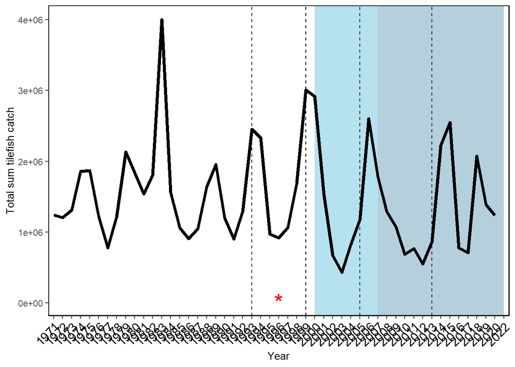

```r
ggplot(recruit, aes(x = factor(year), y = recruit_est, group = 1))+
   geom_rect(aes(xmin = '2007', xmax = '2022', ymin = -Inf, ymax = Inf),
            fill = 'red', alpha = 0.02) +
  geom_rect(aes(xmin = '2000', xmax = '2022', ymin = -Inf, ymax = Inf),
            fill = 'lightblue', alpha = 0.05) +
   geom_vline(xintercept = c('1993','1999', '2005', '2013'), lty = 2) +
  geom_line(color = 'black', size = 1.5) +
  annotate("text", label = "*",
    x = 26, y = 14000, size = 8, colour = "red" )+
  xlab('Year') +
  ylab('Total sum tilefish catch') +
  # facet_wrap(~month)+
  theme(axis.text.x = element_text(color = 'black',
                                   size = 12, angle = 45, vjust = 1, hjust=1)) +
  ecodata::theme_facet()
```

```r
### Thought: Should we isolate years associated w/strong year classes (or bad)
###           for correlations and analyses?
```

##### SST

```r
# SST
sst<-read.csv(here::here('data/sst/sst_ts_gtf_strata.csv'))
```

```r
# SST with season lag
sst.lag <- sst %>%
  arrange(year, month) %>%
  mutate(sst_lag3 = lag(weighted_mean_sst,3),
         sst_lag6 = lag(weighted_mean_sst,6),
         sst_lag9 = lag(weighted_mean_sst,9),
         sst_lag12 = lag(weighted_mean_sst,12))

# Join with recruit estimate
df <- dplyr::full_join(recruit, sst.lag %>%
                   group_by(year) %>%
                   filter(year %in% c(2000:2020)),
dplyr::select(year, month, recruit.est, mean_sst, weighted_mean_sst, sst_lag3, sst_lag6, sst_lag9, sst_lag12),
                 by = join_by(year))
sst.rec <- df[-c(1:29),] #removes year < 2000 (when SST data begins)

#by season
sst_winter <- filter(sst.rec, month %in% c(1,2,3))
sst_spring <- filter(sst.rec, month %in% c(4,5,6))
sst_summer <- filter(sst.rec, month %in% c(7,8,9))
sst_fall <- filter(sst.rec, month %in% c(10,11,12))
```

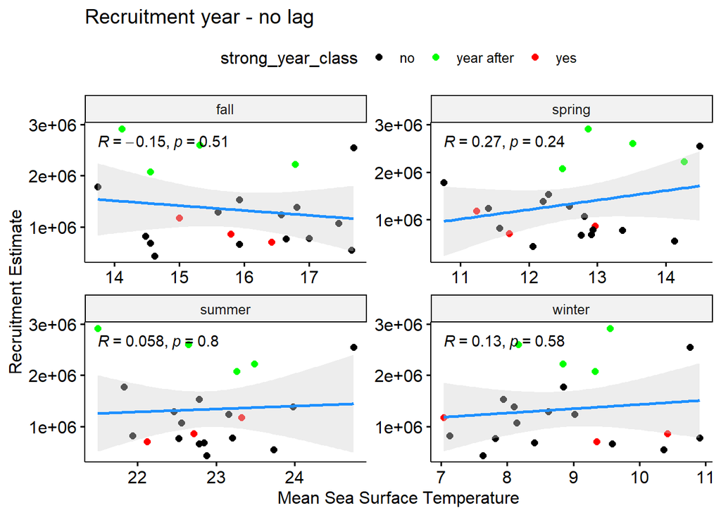

```r
df = sst.rec %>%
  mutate(season = case_when(month %in% c(1,2,3) ~ 'winter',
                            month %in% c(4,5,6) ~ 'spring',
                            month %in% c(7,8,9) ~ 'summer',
                            month %in% c(10,11,12) ~ 'fall'),
         strong_year_class = case_when(year %in% c(2005,2013,2017) ~ 'yes',
                                  year %in% c(2000,2006,2014,2018) ~ 'year after',
                                  year %in% c(2001:2004,2007:2012,2015:2016,2019:2020) ~ 'no'))


df %>% group_by(year, season, strong_year_class) %>%
  summarize(sst = mean(weighted_mean_sst),
            r = mean(recruit_est)) %>%
  ggscatter(x = "sst", y = "r",
            add = "reg.line", conf.int = TRUE,
            color = "strong_year_class", palette = c("black", "green", "red"),
            cor.coef = TRUE, cor.coeff.args = list(method="pearson"),
            add.params=list(color="dodgerblue", fill="lightgray"),
            xlab = "Mean Sea Surface Temperature", ylab = "Recruitment Estimate",
            title="Recruitment year - no lag") +
  facet_wrap(~season, scales = 'free')
```

Here we have SST lagged by 1 year - by season (updated 12/19)

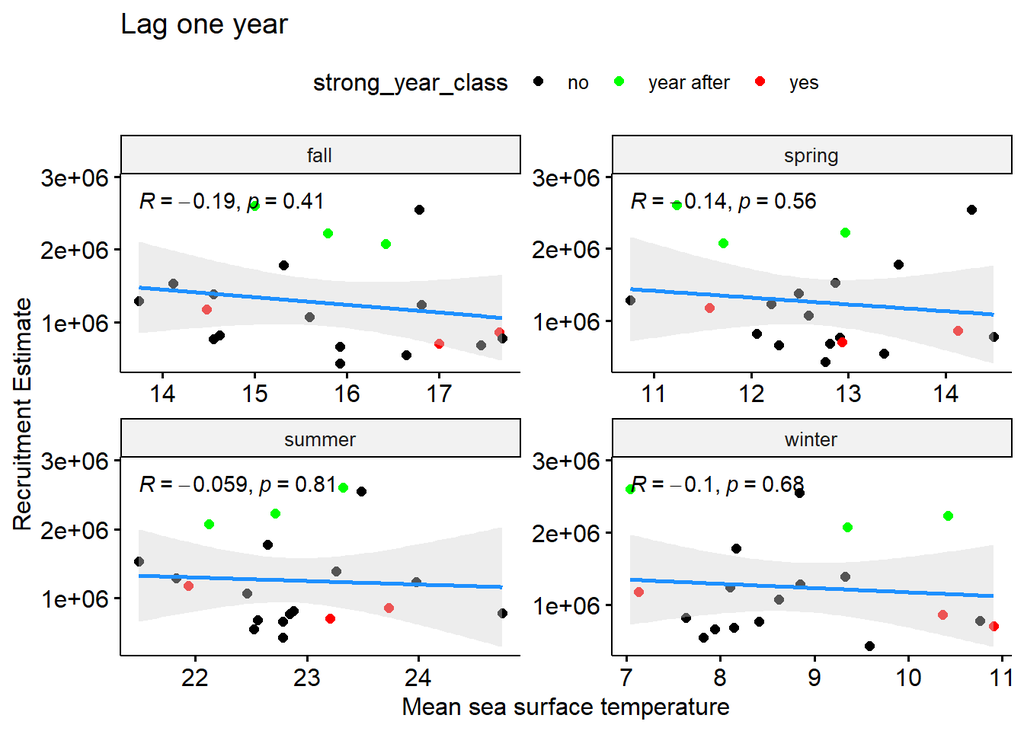

```r
df %>% group_by(year, season, strong_year_class) %>%
  summarize(sst = mean(sst_lag12),
            r = mean(recruit_est)) %>%
  ggscatter(x = "sst", y = "r",
            add = "reg.line", conf.int = TRUE,
            color = "strong_year_class", palette = c("black", "green", "red"),
            cor.coef = TRUE, cor.coeff.args = list(method="pearson"),
            add.params=list(color="dodgerblue", fill="lightgray"),
            xlab = "Mean sea surface temperature", ylab = "Recruitment Estimate",
            title="Lag one year")+
  facet_wrap(~season, scales = 'free')
```

Seasonal lag

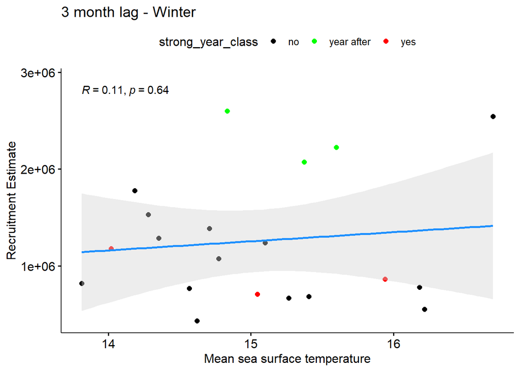

```r
## 3 month lag (winter)

df %>% group_by(year, strong_year_class) %>%
  summarize(sst = mean(sst_lag3),
            r = mean(recruit_est)) %>%
  ggscatter(x = "sst", y = "r",
            add = "reg.line", conf.int = TRUE,
            color = "strong_year_class", palette = c("black", "green", "red"),
            cor.coef = TRUE, cor.coeff.args = list(method="pearson"),
            add.params=list(color="dodgerblue", fill="lightgray"),
            xlab = "Mean sea surface temperature", ylab = "Recruitment Estimate",
            title="3 month lag - Winter")
```

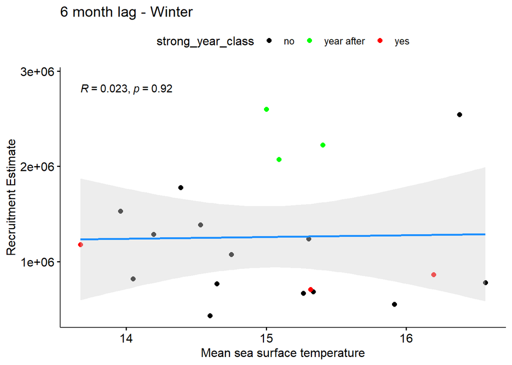

```r
## 6 month lag (winter)

df %>% group_by(year, strong_year_class) %>%
  summarize(sst = mean(sst_lag6),
            r = mean(recruit_est)) %>%
  ggscatter(x = "sst", y = "r",
            add = "reg.line", conf.int = TRUE,
            color = "strong_year_class", palette = c("black", "green", "red"),
            cor.coef = TRUE, cor.coeff.args = list(method="pearson"),
            add.params=list(color="dodgerblue", fill="lightgray"),
            xlab = "Mean sea surface temperature", ylab = "Recruitment Estimate",
            title="6 month lag - Winter")
```

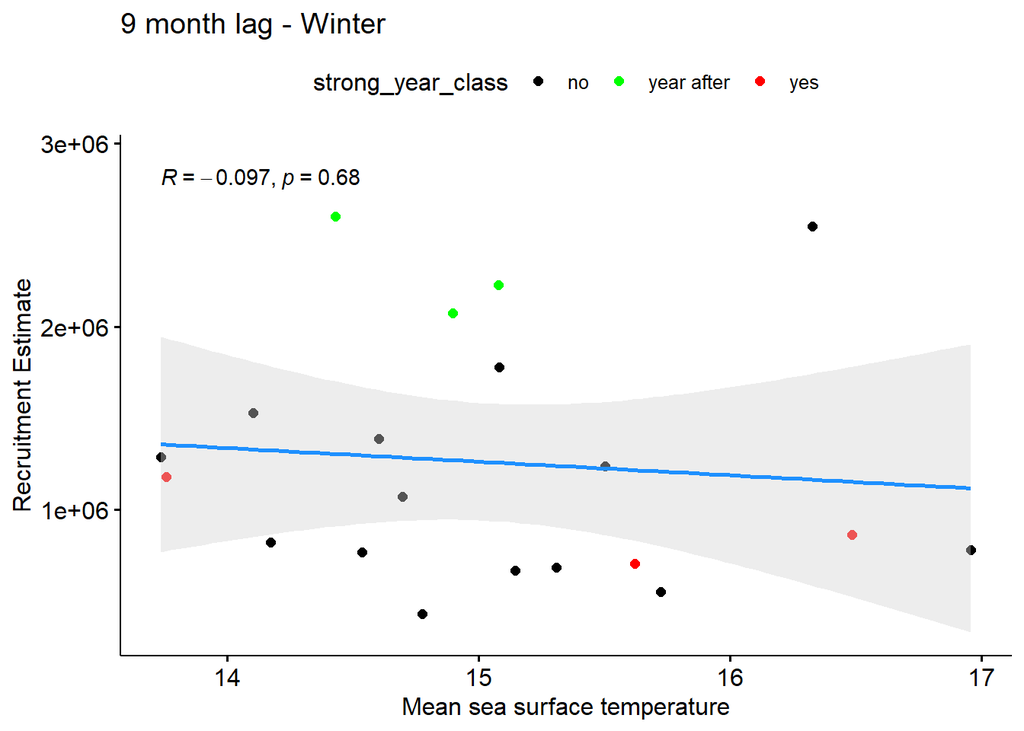

```r
## 9 month lag (winter)

df %>% group_by(year, strong_year_class) %>%
  summarize(sst = mean(sst_lag9),
            r = mean(recruit_est)) %>%
  ggscatter(x = "sst", y = "r",
            add = "reg.line", conf.int = TRUE,
            color = "strong_year_class", palette = c("black", "green", "red"),
            cor.coef = TRUE, cor.coeff.args = list(method="pearson"),
            add.params=list(color="dodgerblue", fill="lightgray"),
            xlab = "Mean sea surface temperature", ylab = "Recruitment Estimate",
            title="9 month lag - Winter")
```

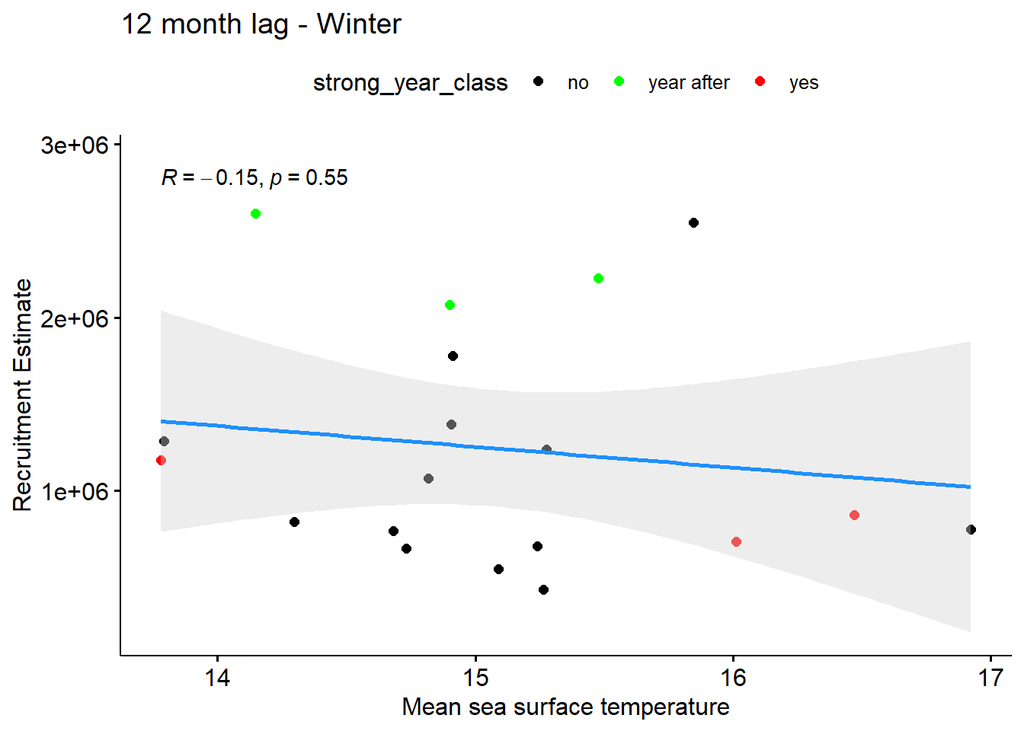

```r
## 12 month lag (winter)

df %>% group_by(year, strong_year_class) %>%
  summarize(sst = mean(sst_lag12),
            r = mean(recruit_est)) %>%
  ggscatter(x = "sst", y = "r",
            add = "reg.line", conf.int = TRUE,
            color = "strong_year_class", palette = c("black", "green", "red"),
            cor.coef = TRUE, cor.coeff.args = list(method="pearson"),
            add.params=list(color="dodgerblue", fill="lightgray"),
            xlab = "Mean sea surface temperature", ylab = "Recruitment Estimate",
            title="12 month lag - Winter")
```

##### Bottom T analysis

The following figures compare in-situ bottom temperature from the study-fleet data set to the recruitment estimate.

- Note here temperatures are averaged across all depths > 50 for each month.

```r
bt <- read.csv(here::here('data/bottom_temp/bt_ts_gtf_1970_2023.csv'))

# BT with year lag
bt.lag <- bt %>%
  filter(year %in% c(1997:2020)) %>%
  mutate(bt_lag3 = lag(weighted_mean_bt,3),
         bt_lag6 = lag(weighted_mean_bt,6),
         bt_lag9 = lag(weighted_mean_bt,9),
         bt_lag12 = lag(weighted_mean_bt,12))

# Join with recruit estimate
bt.rec <- dplyr::full_join(recruit, bt.lag, by = join_by(year)) %>%
  dplyr::select(year, month, recruit_est, weighted_mean_bt, bt_lag3, bt_lag6, bt_lag9, bt_lag12) %>%
  tidyr::drop_na()


#by season
bt_winter <- filter(bt.rec, month %in% c(1,2,3))
bt_spring <- filter(bt.rec, month %in% c(4,5,6))
bt_summer <- filter(bt.rec, month %in% c(7,8,9))
bt_fall <- filter(bt.rec, month %in% c(10,11,12))
```

Here is bottom temp and recruitment not lagged

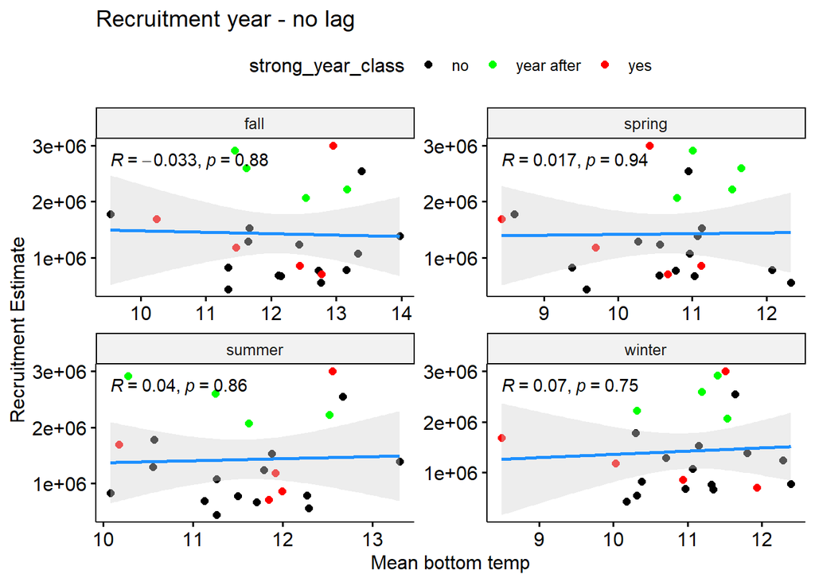

```r
df = bt.rec %>%
  mutate(season = case_when(month %in% c(1,2,3) ~ 'winter',
                            month %in% c(4,5,6) ~ 'spring',
                            month %in% c(7,8,9) ~ 'summer',
                            month %in% c(10,11,12) ~ 'fall'),
         strong_year_class = case_when(year %in% c(1998,1999,2005,2013,2017) ~ 'yes',
                                  year %in% c(2000,2006,2014,2018) ~ 'year after',
                                  year %in% c(2001:2004,2007:2012,2015:2016,2019:2020) ~ 'no'))


df %>% group_by(year, season, strong_year_class) %>%
  summarize(bt = mean(weighted_mean_bt),
            r = mean(recruit_est)) %>%
  ggscatter(x = "bt", y = "r",
            add = "reg.line", conf.int = TRUE,
            color = "strong_year_class", palette = c("black", "green", "red"),
            cor.coef = TRUE, cor.coeff.args = list(method="pearson"),
            add.params=list(color="dodgerblue", fill="lightgray"),
            xlab = "Mean bottom temp", ylab = "Recruitment Estimate",
            title="Recruitment year - no lag")+
  facet_wrap(~season, scales = 'free')
```

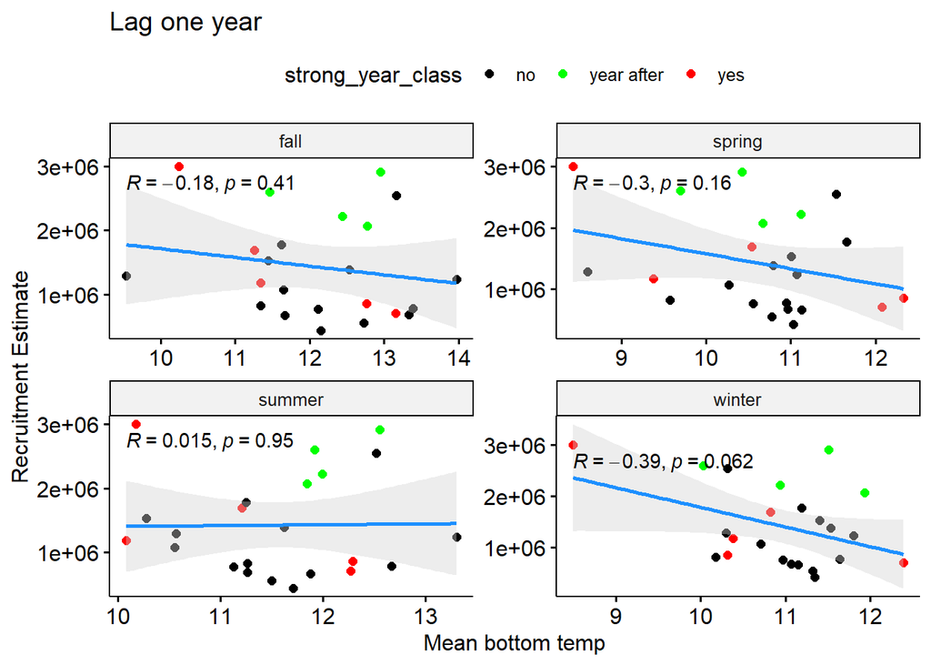

```r
df %>% group_by(year, season, strong_year_class) %>%
  summarize(bt = mean(bt_lag12),
            r = mean(recruit_est)) %>%
  ggscatter(x = "bt", y = "r",
            add = "reg.line", conf.int = TRUE,
            color = "strong_year_class", palette = c("black", "green", "red"),
            cor.coef = TRUE, cor.coeff.args = list(method="pearson"),
            add.params=list(color="dodgerblue", fill="lightgray"),
            xlab = "Mean bottom temp", ylab = "Recruitment Estimate",
            title="Lag one year")+
  facet_wrap(~season, scales = 'free')
```

Seasonal lag

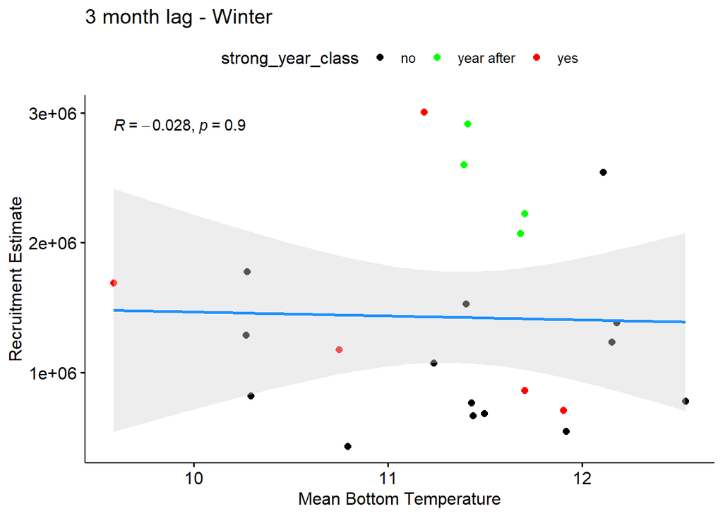

```r
## 3 month lag (winter)

df %>% group_by(year, strong_year_class) %>%
  summarize(bt = mean(bt_lag3),
            r = mean(recruit_est)) %>%
  ggscatter(x = "bt", y = "r",
            add = "reg.line", conf.int = TRUE,
            color = "strong_year_class", palette = c("black", "green", "red"),
            cor.coef = TRUE, cor.coeff.args = list(method="pearson"),
            add.params=list(color="dodgerblue", fill="lightgray"),
            xlab = "Mean Bottom Temperature", ylab = "Recruitment Estimate",
            title="3 month lag - Winter")
```

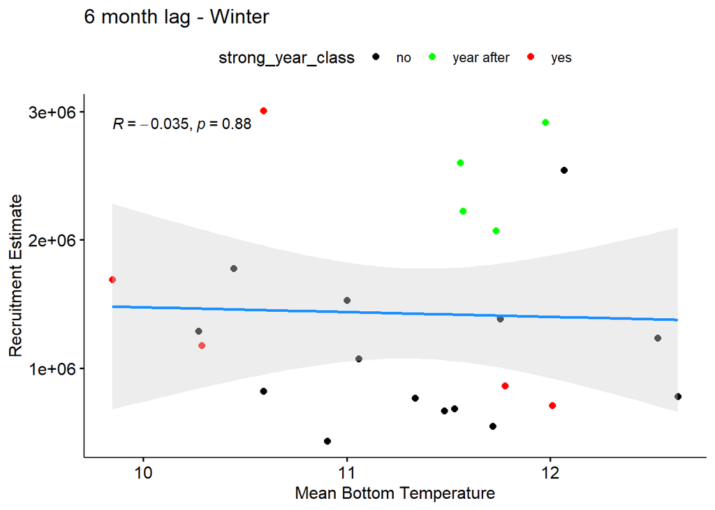

```r
## 6 month lag (winter)

df %>% group_by(year, strong_year_class) %>%
  summarize(bt = mean(bt_lag6),
            r = mean(recruit_est)) %>%
  ggscatter(x = "bt", y = "r",
            add = "reg.line", conf.int = TRUE,
            color = "strong_year_class", palette = c("black", "green", "red"),
            cor.coef = TRUE, cor.coeff.args = list(method="pearson"),
            add.params=list(color="dodgerblue", fill="lightgray"),
            xlab = "Mean Bottom Temperature", ylab = "Recruitment Estimate",
            title="6 month lag - Winter")
```

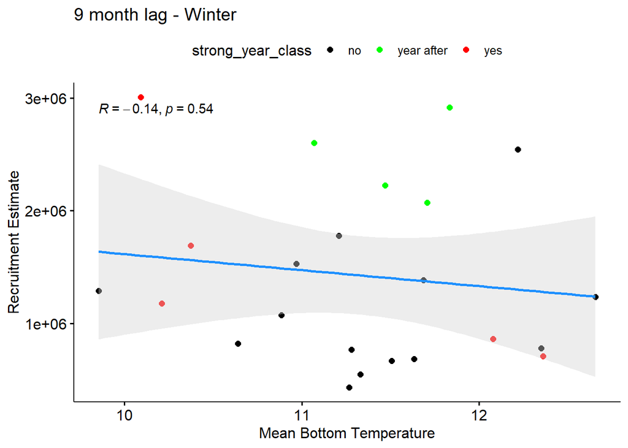

```r
## 9 month lag (winter)
df %>% group_by(year, strong_year_class) %>%
  summarize(bt = mean(bt_lag9),
            r = mean(recruit_est)) %>%
  ggscatter(x = "bt", y = "r",
            add = "reg.line", conf.int = TRUE,
            color = "strong_year_class", palette = c("black", "green", "red"),
            cor.coef = TRUE, cor.coeff.args = list(method="pearson"),
            add.params=list(color="dodgerblue", fill="lightgray"),
            xlab = "Mean Bottom Temperature", ylab = "Recruitment Estimate",
            title="9 month lag - Winter")
```

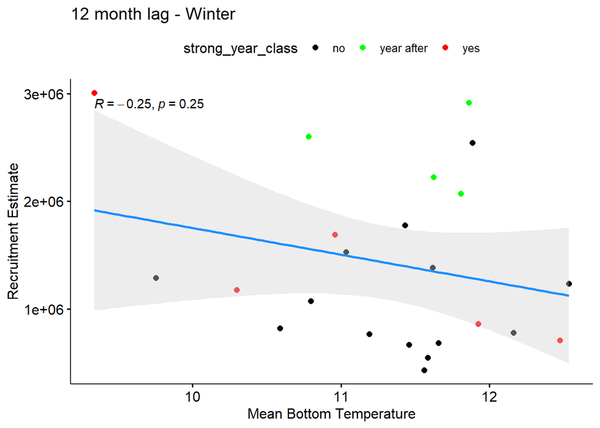

```r
## 12 month lag (winter)
df %>% group_by(year, strong_year_class) %>%
  summarize(bt = mean(bt_lag12),
            r = mean(recruit_est)) %>%
  ggscatter(x = "bt", y = "r",
            add = "reg.line", conf.int = TRUE,
            color = "strong_year_class", palette = c("black", "green", "red"),
            cor.coef = TRUE, cor.coeff.args = list(method="pearson"),
            add.params=list(color="dodgerblue", fill="lightgray"),
            xlab = "Mean Bottom Temperature", ylab = "Recruitment Estimate",
            title="12 month lag - Winter")
```

##### Salinity

Here we explore salinity from the GLORYS reanalysis model at three different depths

- 78 meters (relevant to larvae, recruits)
- 92 meters (relevant recruits, juveniles)
- 110 meters (relevant to juveniles, adults)

##### Salinity analysis

78 Meters

```r
# Read in data at 78 m depth
sal78 <- read.csv(here::here('data/salinity/sal_78m_monthly_ts_gtf.csv'))

# sal78m with year lag
sal78.lag <- sal78 %>%
  filter(year %in% c(1997:2020)) %>%
  mutate(sal78_lag3 = lag(weighted_mean_sal_78m,3),
         sal78_lag6 = lag(weighted_mean_sal_78m,6),
         sal78_lag9 = lag(weighted_mean_sal_78m,9),
         sal78_lag12 = lag(weighted_mean_sal_78m,12),
         year = as.numeric(year))


# Join with recruit estimate
sal78.rec <- dplyr::full_join(recruit, sal78.lag, by = join_by(year)) %>%
  dplyr::select(year, month, recruit_est, weighted_mean_sal_78m, sal78_lag3, sal78_lag6, sal78_lag9, sal78_lag12) %>%
  tidyr::drop_na()
```

No lag, 1 year lag, seasonal lags

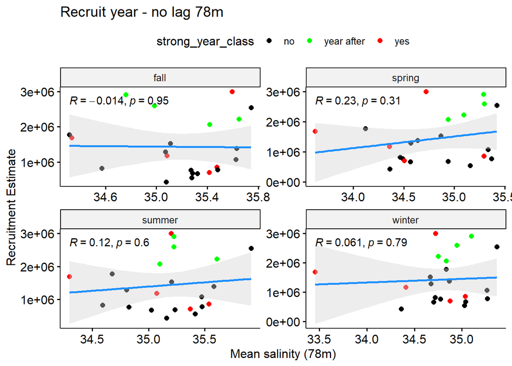

```r
df = sal78.rec %>%
  mutate(season = case_when(month %in% c(1,2,3) ~ 'winter',
                            month %in% c(4,5,6) ~ 'spring',
                            month %in% c(7,8,9) ~ 'summer',
                            month %in% c(10,11,12) ~ 'fall'),
         strong_year_class = case_when(year %in% c(1998,1999,2005,2013,2017) ~ 'yes',
                                  year %in% c(2000,2006,2014,2018) ~ 'year after',
                                  year %in% c(2001:2004,2007:2012,2015:2016,2019:2020) ~ 'no'))

# Plot without lag
df %>% group_by(year, season, strong_year_class) %>%
  summarize(sal78 = mean(weighted_mean_sal_78m),
            r = mean(recruit_est)) %>%
  ggscatter(x = "sal78", y = "r",
            add = "reg.line", conf.int = TRUE,
            color = "strong_year_class", palette = c("black", "green", "red"),
            cor.coef = TRUE, cor.coeff.args = list(method="pearson"),
            add.params=list(color="dodgerblue", fill="lightgray"),
            xlab = "Mean salinity (78m)", ylab = "Recruitment Estimate",
            title="Recruit year - no lag 78m")+
  facet_wrap(~season, scales = 'free')
```

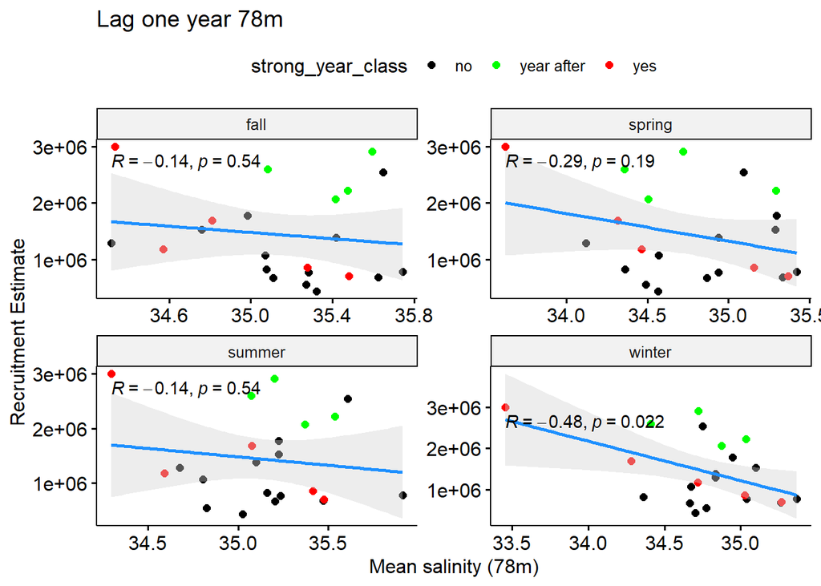

```r
# Plot with lag
df %>% group_by(year, season, strong_year_class) %>%
  summarize(sal78 = mean(sal78_lag12),
            r = mean(recruit_est)) %>%
  ggscatter(x = "sal78", y = "r",
            add = "reg.line", conf.int = TRUE,
            color = "strong_year_class", palette = c("black", "green", "red"),
            cor.coef = TRUE, cor.coeff.args = list(method="pearson"),
            add.params=list(color="dodgerblue", fill="lightgray"),
            xlab = "Mean salinity (78m)", ylab = "Recruitment Estimate",
            title="Lag one year 78m")+
  facet_wrap(~season, scales = 'free')
```

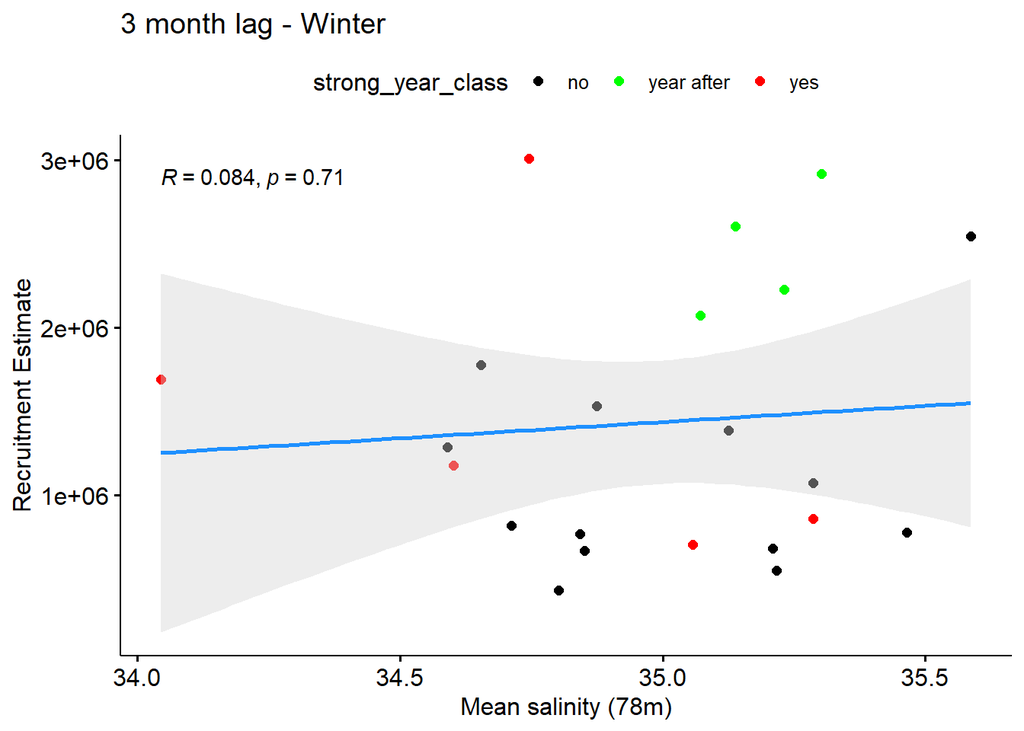

```r
#### Computing correlations
# win.cor = df %>% filter(season == 'winter')
# print(paste0('correlation coeff: ', round(cor(win.cor[,3], win.cor[,5]), 4)))
# fal.cor = df %>% filter(season == 'fall')
# print(paste0('correlation coeff: ', round(cor(fal.cor[,3], fal.cor[,4]), 4)))

## 3 month lag (winter)

df %>% group_by(year, strong_year_class) %>%
  summarize(sal78 = mean(sal78_lag3),
            r = mean(recruit_est)) %>%
  ggscatter(x = "sal78", y = "r",
            add = "reg.line", conf.int = TRUE,
            color = "strong_year_class", palette = c("black", "green", "red"),
            cor.coef = TRUE, cor.coeff.args = list(method="pearson"),
            add.params=list(color="dodgerblue", fill="lightgray"),
            xlab = "Mean salinity (78m)", ylab = "Recruitment Estimate",
            title="3 month lag - Winter")
```

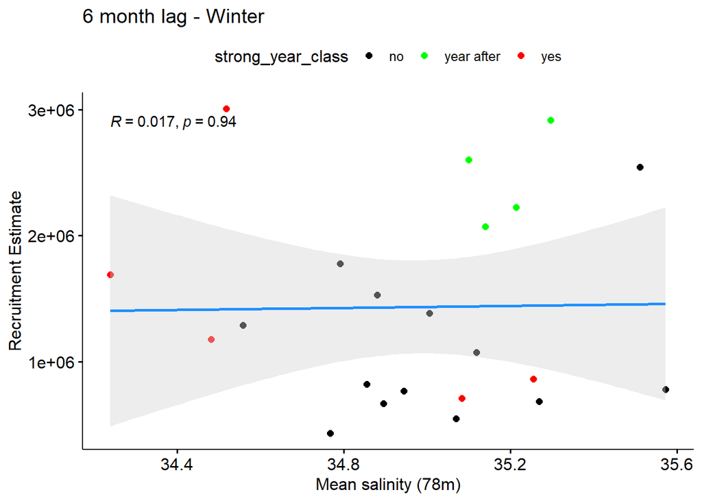

```r
## 6 month lag (winter)

df %>% group_by(year, strong_year_class) %>%
  summarize(sal78 = mean(sal78_lag6),
            r = mean(recruit_est)) %>%
  ggscatter(x = "sal78", y = "r",
            add = "reg.line", conf.int = TRUE,
            color = "strong_year_class", palette = c("black", "green", "red"),
            cor.coef = TRUE, cor.coeff.args = list(method="pearson"),
            add.params=list(color="dodgerblue", fill="lightgray"),
            xlab = "Mean salinity (78m)", ylab = "Recruitment Estimate",
            title="6 month lag - Winter")
```

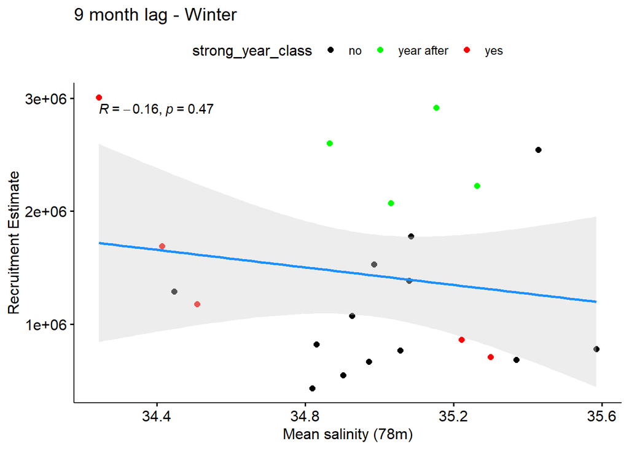

```r
## 9 month lag (winter)

df %>% group_by(year, strong_year_class) %>%
  summarize(sal78 = mean(sal78_lag9),
            r = mean(recruit_est)) %>%
  ggscatter(x = "sal78", y = "r",
            add = "reg.line", conf.int = TRUE,
            color = "strong_year_class", palette = c("black", "green", "red"),
            cor.coef = TRUE, cor.coeff.args = list(method="pearson"),
            add.params=list(color="dodgerblue", fill="lightgray"),
            xlab = "Mean salinity (78m)", ylab = "Recruitment Estimate",
            title="9 month lag - Winter")
```

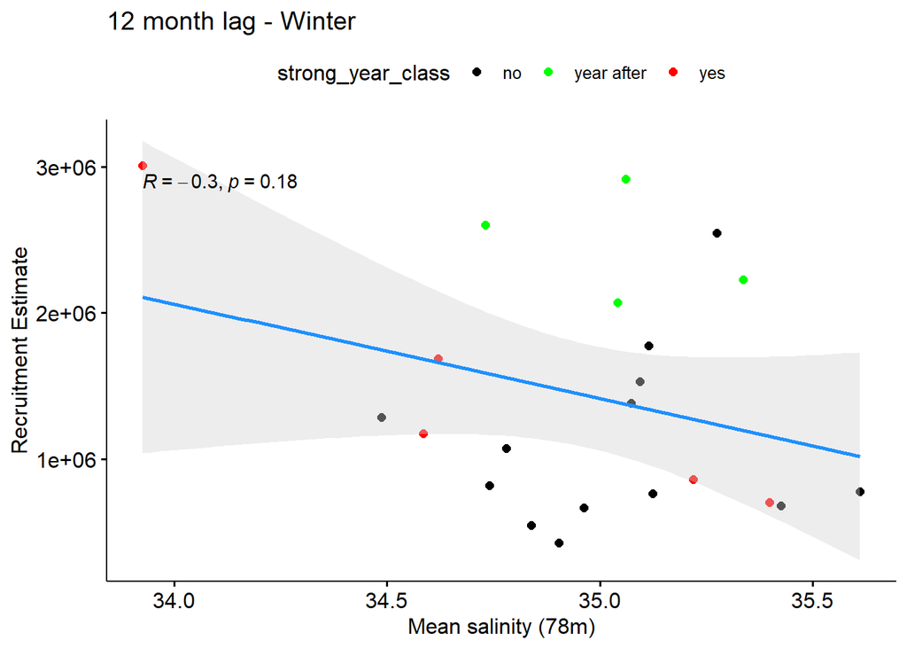

```r
## 12 month lag (winter)

df %>% group_by(year, strong_year_class) %>%
  summarize(sal78 = mean(sal78_lag12),
            r = mean(recruit_est)) %>%
  ggscatter(x = "sal78", y = "r",
            add = "reg.line", conf.int = TRUE,
            color = "strong_year_class", palette = c("black", "green", "red"),
            cor.coef = TRUE, cor.coeff.args = list(method="pearson"),
            add.params=list(color="dodgerblue", fill="lightgray"),
            xlab = "Mean salinity (78m)", ylab = "Recruitment Estimate",
            title="12 month lag - Winter")
```

92 Meters

```r
# Read in data at 92 meter depth

sal92 <- read.csv(here::here('data/salinity/sal_92m_monthly_ts_gtf.csv'))

sal92.lag <- sal92 %>%
  filter(year %in% c(1997:2020)) %>%
  mutate(sal92_lag3 = lag(weighted_mean_sal_92m,3),
         sal92_lag6 = lag(weighted_mean_sal_92m,6),
         sal92_lag9 = lag(weighted_mean_sal_92m,9),
         sal92_lag12 = lag(weighted_mean_sal_92m,12),
         year = as.numeric(year))


# Join with recruit estimate
sal92.rec <- dplyr::full_join(recruit, sal92.lag, by = join_by(year)) %>%
  dplyr::select(year, month, recruit_est, weighted_mean_sal_92m, sal92_lag3, sal92_lag6, sal92_lag9, sal92_lag12) %>%
  tidyr::drop_na()
```

No lag, 1 year lag, and seasonal lag plots

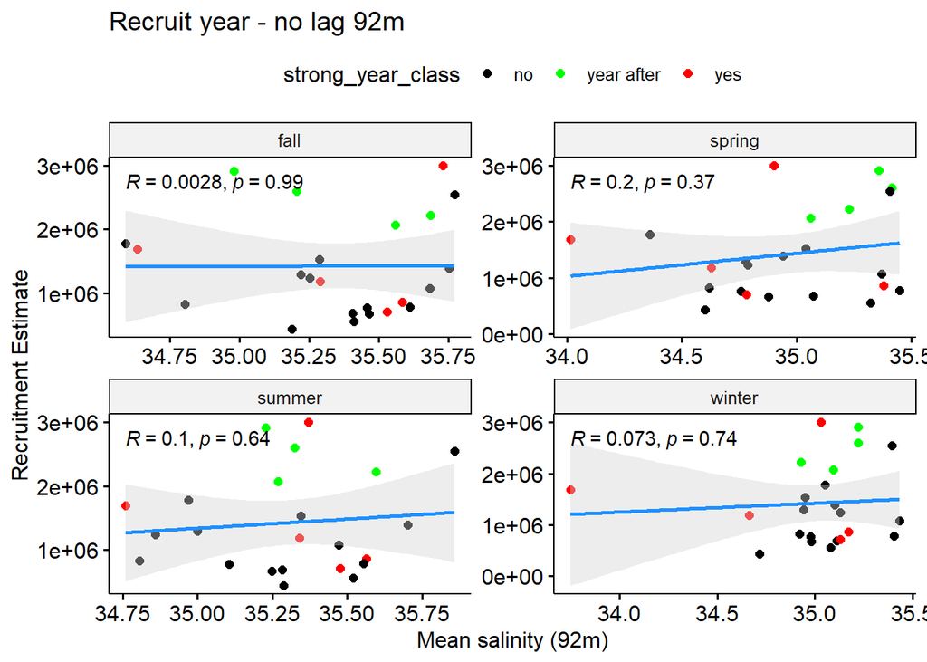

```r
df = sal92.rec %>%
  mutate(season = case_when(month %in% c(1,2,3) ~ 'winter',
                            month %in% c(4,5,6) ~ 'spring',
                            month %in% c(7,8,9) ~ 'summer',
                            month %in% c(10,11,12) ~ 'fall'),
         strong_year_class = case_when(year %in% c(1998,1999,2005,2013,2017) ~ 'yes',
                                  year %in% c(2000,2006,2014,2018) ~ 'year after',
                                  year %in% c(2001:2004,2007:2012,2015:2016,2019:2020) ~ 'no'))

# Plot without lag
df %>% group_by(year, season, strong_year_class) %>%
  summarize(sal92 = mean(weighted_mean_sal_92m),
            r = mean(recruit_est)) %>%
  ggscatter(x = "sal92", y = "r",
            add = "reg.line", conf.int = TRUE,
            color = "strong_year_class", palette = c("black", "green", "red"),
            cor.coef = TRUE, cor.coeff.args = list(method="pearson"),
            add.params=list(color="dodgerblue", fill="lightgray"),
            xlab = "Mean salinity (92m)", ylab = "Recruitment Estimate",
            title="Recruit year - no lag 92m")+
  facet_wrap(~season, scales = 'free')
```

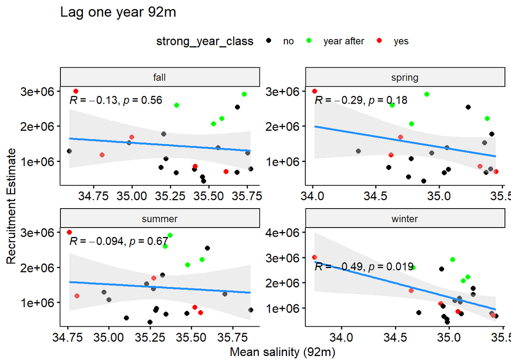

```r
# Plot with lag
df %>% group_by(year, season, strong_year_class) %>%
  summarize(sal92 = mean(sal92_lag12),
            r = mean(recruit_est)) %>%
  ggscatter(x = "sal92", y = "r",
            add = "reg.line", conf.int = TRUE,
            color = "strong_year_class", palette = c("black", "green", "red"),
            cor.coef = TRUE, cor.coeff.args = list(method="pearson"),
            add.params=list(color="dodgerblue", fill="lightgray"),
            xlab = "Mean salinity (92m)", ylab = "Recruitment Estimate",
            title="Lag one year 92m")+
  facet_wrap(~season, scales = 'free')
```

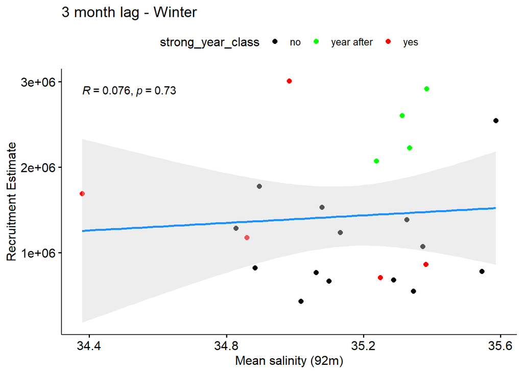

```r
#### Computing correlations
# win.cor = df %>% filter(season == 'winter')
# print(paste0('correlation coeff: ', round(cor(win.cor[,3], win.cor[,5]), 4)))
# fal.cor = df %>% filter(season == 'fall')
# print(paste0('correlation coeff: ', round(cor(fal.cor[,3], fal.cor[,4]), 4)))

## 3 month lag (winter)

df %>% group_by(year, strong_year_class) %>%
  summarize(sal92 = mean(sal92_lag3),
            r = mean(recruit_est)) %>%
  ggscatter(x = "sal92", y = "r",
            add = "reg.line", conf.int = TRUE,
            color = "strong_year_class", palette = c("black", "green", "red"),
            cor.coef = TRUE, cor.coeff.args = list(method="pearson"),
            add.params=list(color="dodgerblue", fill="lightgray"),
            xlab = "Mean salinity (92m)", ylab = "Recruitment Estimate",
            title="3 month lag - Winter")
```

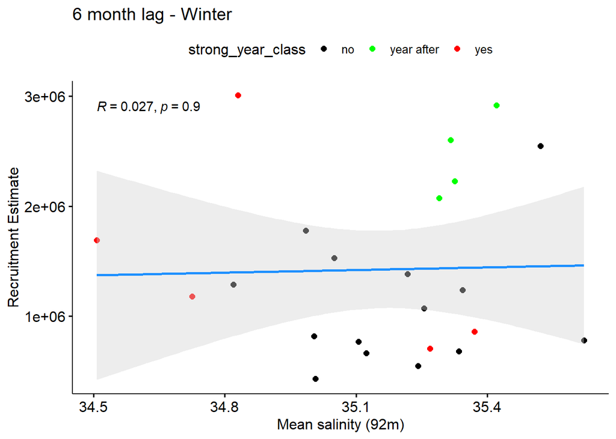

```r
## 6 month lag (winter)

df %>% group_by(year, strong_year_class) %>%
  summarize(sal92 = mean(sal92_lag6),
            r = mean(recruit_est)) %>%
  ggscatter(x = "sal92", y = "r",
            add = "reg.line", conf.int = TRUE,
            color = "strong_year_class", palette = c("black", "green", "red"),
            cor.coef = TRUE, cor.coeff.args = list(method="pearson"),
            add.params=list(color="dodgerblue", fill="lightgray"),
            xlab = "Mean salinity (92m)", ylab = "Recruitment Estimate",
            title="6 month lag - Winter")
```

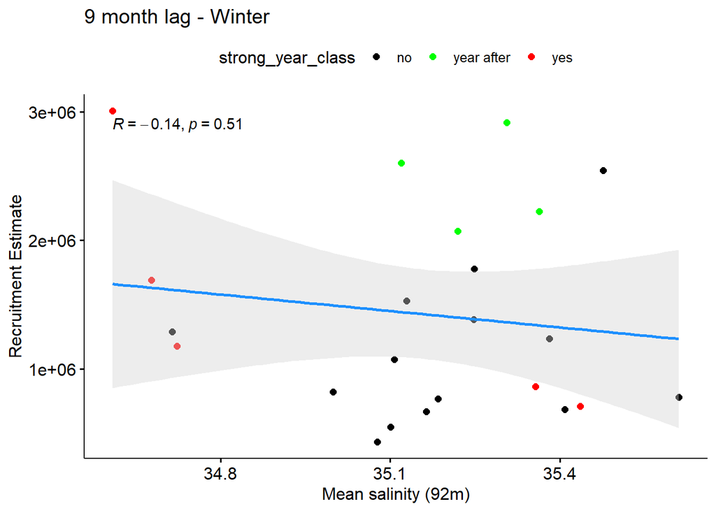

```r
## 9 month lag (winter)

df %>% group_by(year, strong_year_class) %>%
  summarize(sal92 = mean(sal92_lag9),
            r = mean(recruit_est)) %>%
  ggscatter(x = "sal92", y = "r",
            add = "reg.line", conf.int = TRUE,
            color = "strong_year_class", palette = c("black", "green", "red"),
            cor.coef = TRUE, cor.coeff.args = list(method="pearson"),
            add.params=list(color="dodgerblue", fill="lightgray"),
            xlab = "Mean salinity (92m)", ylab = "Recruitment Estimate",
            title="9 month lag - Winter")
```

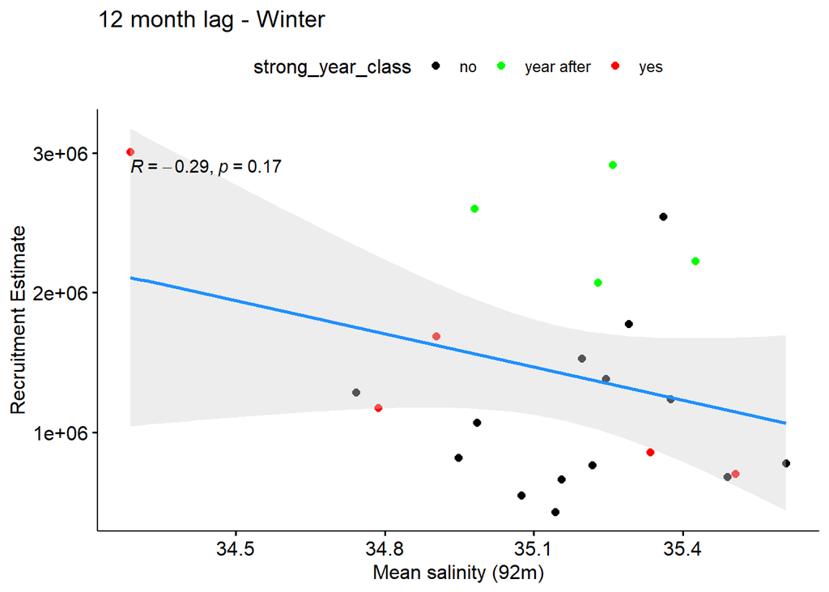

```r
## 12 month lag (winter)

df %>% group_by(year, strong_year_class) %>%
  summarize(sal92 = mean(sal92_lag12),
            r = mean(recruit_est)) %>%
  ggscatter(x = "sal92", y = "r",
            add = "reg.line", conf.int = TRUE,
            color = "strong_year_class", palette = c("black", "green", "red"),
            cor.coef = TRUE, cor.coeff.args = list(method="pearson"),
            add.params=list(color="dodgerblue", fill="lightgray"),
            xlab = "Mean salinity (92m)", ylab = "Recruitment Estimate",
            title="12 month lag - Winter")
```

```r
#### Computing correlations
# win.cor = df %>% filter(season == 'winter')
# print(paste0('correlation coeff: ', round(cor(win.cor[,3], win.cor[,5]), 4)))
# fal.cor = df %>% filter(season == 'fall')
# print(paste0('correlation coeff: ', round(cor(fal.cor[,3], fal.cor[,4]), 4)))
```

110 Meters

```r
# Wrangling the data
sal110 <- read.csv(here::here('data/salinity/sal_110m_monthly_ts_gtf.csv'))

#sal110 with lags
sal110.lag <- sal110 %>%
  filter(year %in% c(1997:2020)) %>%
  mutate(sal110_lag3 = lag(weighted_mean_sal_110m,3),
         sal110_lag6 = lag(weighted_mean_sal_110m,6),
         sal110_lag9 = lag(weighted_mean_sal_110m,9),
         sal110_lag12 = lag(weighted_mean_sal_110m,12),
         year = as.numeric(year))


# Join with recruit estimate
sal110.rec <- dplyr::full_join(recruit, sal110.lag, by = join_by(year)) %>%
  dplyr::select(year, month, recruit_est, weighted_mean_sal_110m, sal110_lag3, sal110_lag6, sal110_lag9, sal110_lag12) %>%
  tidyr::drop_na()
```

No lag, 1 year lag, and seasonal lag plots

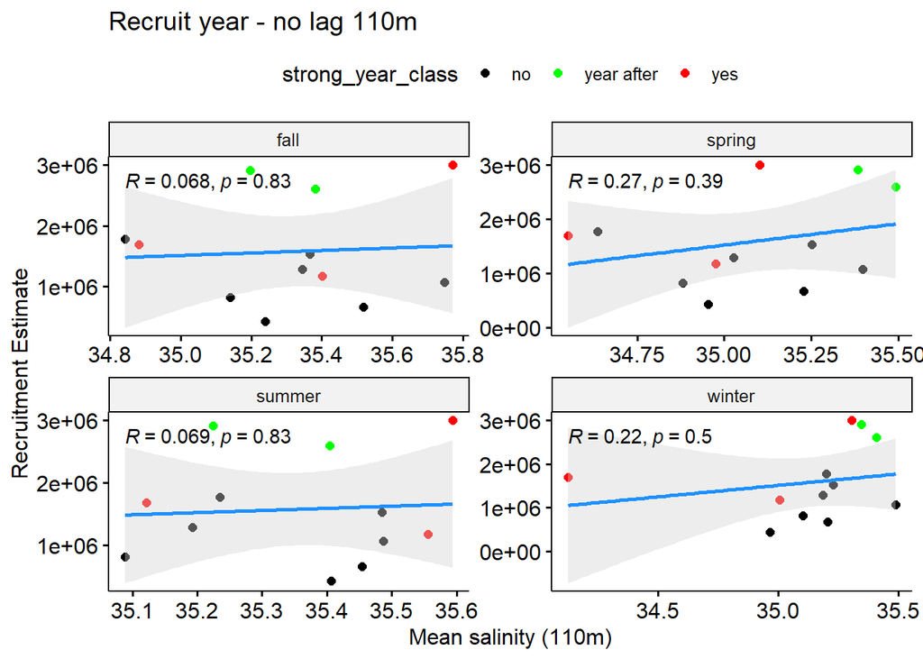

```r
df = sal110.rec %>%
  mutate(season = case_when(month %in% c(1,2,3) ~ 'winter',
                            month %in% c(4,5,6) ~ 'spring',
                            month %in% c(7,8,9) ~ 'summer',
                            month %in% c(10,11,12) ~ 'fall'),
         strong_year_class = case_when(year %in% c(1998,1999,2005,2013,2017) ~ 'yes',
                                  year %in% c(2000,2006,2014,2018) ~ 'year after',
                                  year %in% c(2001:2004,2007:2012,2015:2016,2019:2020) ~ 'no'))

# Plot without lag
df %>% group_by(year, season, strong_year_class) %>%
  summarize(sal110 = mean(weighted_mean_sal_110m),
            r = mean(recruit_est)) %>%
  ggscatter(x = "sal110", y = "r",
            add = "reg.line", conf.int = TRUE,
            color = "strong_year_class", palette = c("black", "green", "red"),
            cor.coef = TRUE, cor.coeff.args = list(method="pearson"),
            add.params=list(color="dodgerblue", fill="lightgray"),
            xlab = "Mean salinity (110m)", ylab = "Recruitment Estimate",
            title="Recruit year - no lag 110m")+
  facet_wrap(~season, scales = 'free')
```

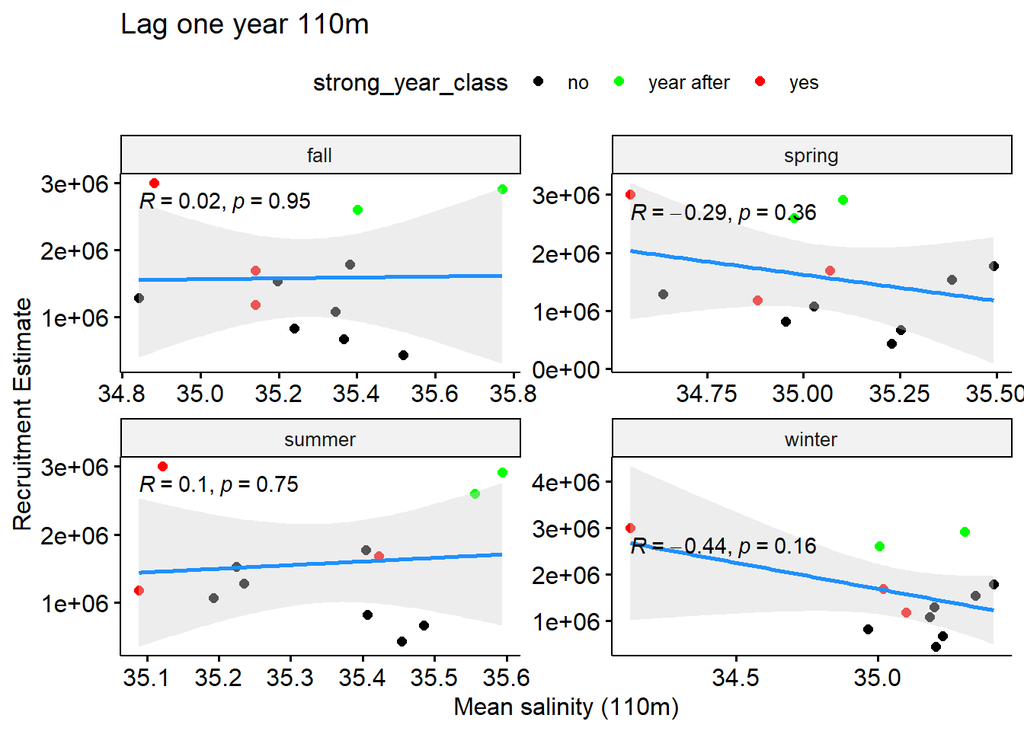

```r
# Plot with lag
df %>% group_by(year, season, strong_year_class) %>%
  summarize(sal110 = mean(sal110_lag12),
            r = mean(recruit_est)) %>%
  ggscatter(x = "sal110", y = "r",
            add = "reg.line", conf.int = TRUE,
            color = "strong_year_class", palette = c("black", "green", "red"),
            cor.coef = TRUE, cor.coeff.args = list(method="pearson"),
            add.params=list(color="dodgerblue", fill="lightgray"),
            xlab = "Mean salinity (110m)", ylab = "Recruitment Estimate",
            title="Lag one year 110m")+
  facet_wrap(~season, scales = 'free')
```

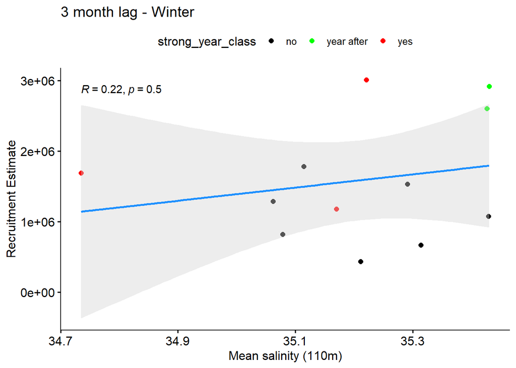

```r
#### Computing correlations
# win.cor = df %>% filter(season == 'winter')
# print(paste0('correlation coeff: ', round(cor(win.cor[,3], win.cor[,5]), 4)))
# fal.cor = df %>% filter(season == 'fall')
# print(paste0('correlation coeff: ', round(cor(fal.cor[,3], fal.cor[,4]), 4)))

## 3 month lag (winter)

df %>% group_by(year, strong_year_class) %>%
  summarize(sal110 = mean(sal110_lag3),
            r = mean(recruit_est)) %>%
  ggscatter(x = "sal110", y = "r",
            add = "reg.line", conf.int = TRUE,
            color = "strong_year_class", palette = c("black", "green", "red"),
            cor.coef = TRUE, cor.coeff.args = list(method="pearson"),
            add.params=list(color="dodgerblue", fill="lightgray"),
            xlab = "Mean salinity (110m)", ylab = "Recruitment Estimate",
            title="3 month lag - Winter")
```

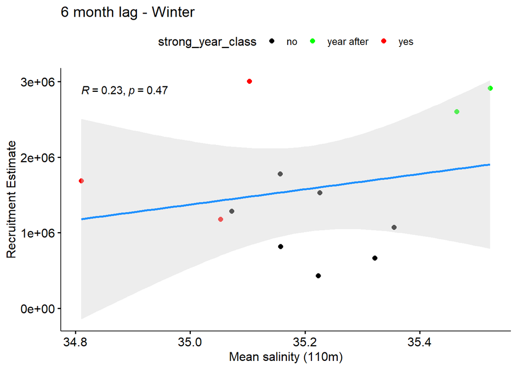

```r
## 6 month lag (winter)

df %>% group_by(year, strong_year_class) %>%
  summarize(sal110 = mean(sal110_lag6),
            r = mean(recruit_est)) %>%
  ggscatter(x = "sal110", y = "r",
            add = "reg.line", conf.int = TRUE,
            color = "strong_year_class", palette = c("black", "green", "red"),
            cor.coef = TRUE, cor.coeff.args = list(method="pearson"),
            add.params=list(color="dodgerblue", fill="lightgray"),
            xlab = "Mean salinity (110m)", ylab = "Recruitment Estimate",
            title="6 month lag - Winter")
```

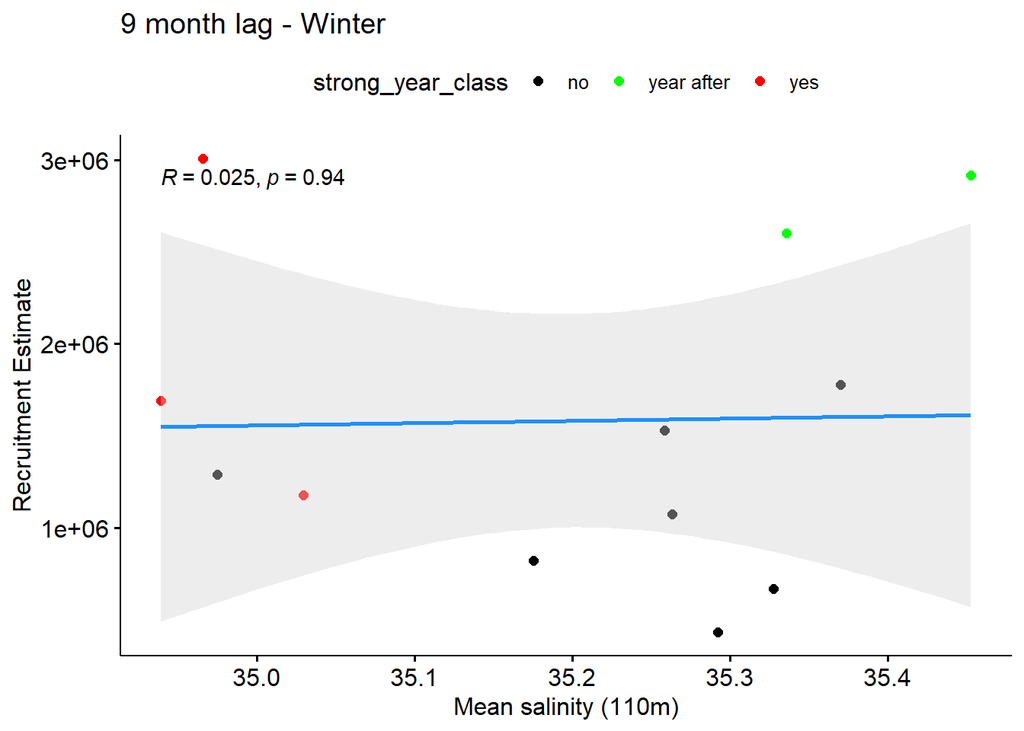

```r
## 9 month lag (winter)

df %>% group_by(year, strong_year_class) %>%
  summarize(sal110 = mean(sal110_lag9),
            r = mean(recruit_est)) %>%
  ggscatter(x = "sal110", y = "r",
            add = "reg.line", conf.int = TRUE,
            color = "strong_year_class", palette = c("black", "green", "red"),
            cor.coef = TRUE, cor.coeff.args = list(method="pearson"),
            add.params=list(color="dodgerblue", fill="lightgray"),
            xlab = "Mean salinity (110m)", ylab = "Recruitment Estimate",
            title="9 month lag - Winter")
```

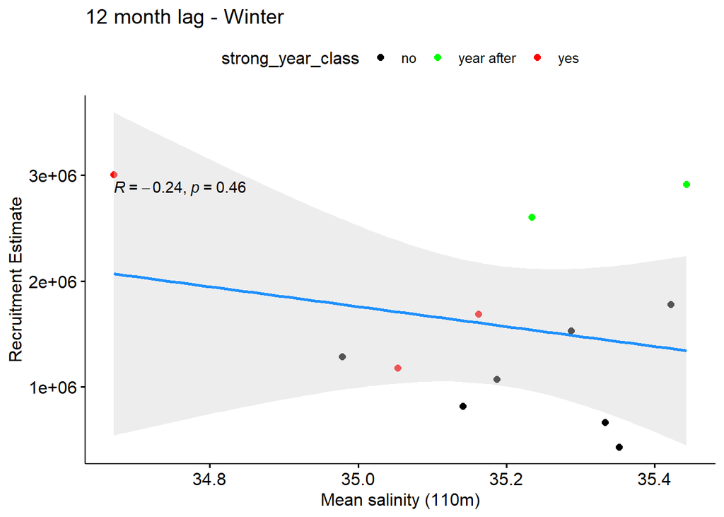

```r
## 12 month lag (winter)

df %>% group_by(year, strong_year_class) %>%
  summarize(sal110 = mean(sal110_lag12),
            r = mean(recruit_est)) %>%
  ggscatter(x = "sal110", y = "r",
            add = "reg.line", conf.int = TRUE,
            color = "strong_year_class", palette = c("black", "green", "red"),
            cor.coef = TRUE, cor.coeff.args = list(method="pearson"),
            add.params=list(color="dodgerblue", fill="lightgray"),
            xlab = "Mean salinity (110m)", ylab = "Recruitment Estimate",
            title="12 month lag - Winter")
```